# UCIRAG HOSPITAL AVELLANEDA

# Introducción

Las infecciones respiratorias agudas (IRAs) constituyen una importante causa de morbimortalidad afectando fundamentalmente a niñas/os menores de cinco años, particularmente aquellos menores de 2 años, adultos mayores y personas susceptibles con patologías de base (cardiovascular, respiratoria, inmunosupresión, entre otras).

En Argentina, todos los años se verifica un progresivo aumento de los casos de IRAs en la época invernal. Dicho aumento se asocia con un incremento en la demanda de atención, del número de hospitalizaciones y de la mortalidad por causas respiratorias.

Las infecciones respiratorias emergentes representan un riesgo importante para la población en virtud de su elevado potencial de transmisión de persona a persona.

Actualmente en la provincia de Tucumán se desarrollan diferentes estrategias de vigilancia epidemiológica de IRAs. La vigilancia epidemiológica sistemática de las infecciones respiratorias agudas graves (IRAG) es fundamental para la caracterización de la situación epidemiológica, detección de eventos inusuales y la implementación oportuna de las medidas de promoción, prevención y control, fortaleciendo la capacidad de respuesta de los servicios de atención y del sector salud en su conjunto.

La Organización Mundial de la Salud recomienda la implementación de sistemas de vigilancia centinela de hospitalizaciones por IRAG (UC-IRAG) que integran la vigilancia de virus respiratorios con potencial epidémico y pandémico: SARS-CoV-2, influenza y virus sincitial respiratorio (VSR). La UC-IRAG en casos hospitalizados se complementa con la vigilancia centinela de estos tres virus en ambulatorios a través de las Unidades de Monitoreo Ambulatorio (UMAs) y ambas permiten caracterizar el espectro de severidad de las infecciones respiratorias agudas de manera integrada.

## Objetivo General

Describir el perfil clínico, epidemiológico y de diagnóstico etiológico de las infecciones respiratorias agudas graves (IRAG) notificadas a través de la estrategia de unidad centinela del Hospital Avellaneda durante el período comprendido entre la SE 18 del 2024 y la SE 30 del 2025

## Ubicación geográfica

[interactive chart not shown]

# Análisis de la UCIRAG de la Provincia de Tucumán

## Casos de IRAG e IRAG extendida segun Semana Epidemiológica - UC-IRAG Hospital Avellaneda -Año 2024 y 2025

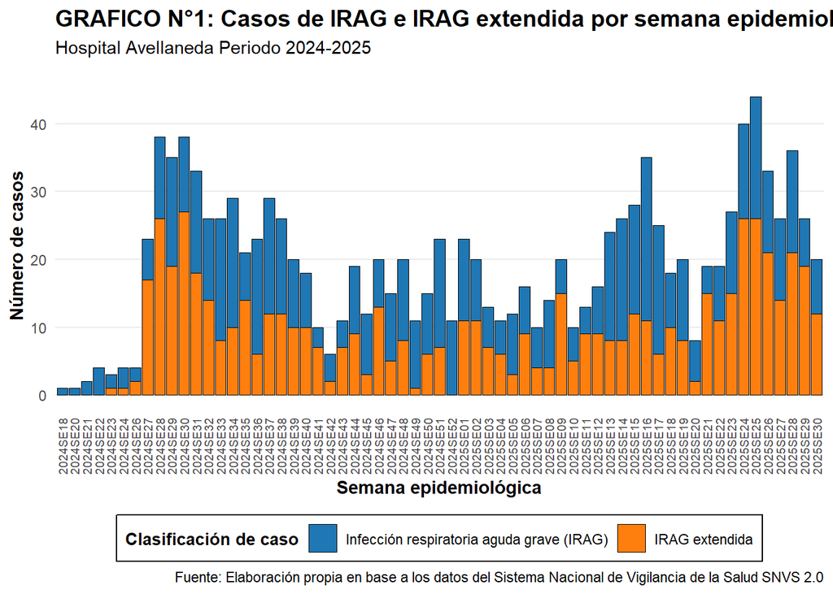

## Casos de IRAG e IRAG extendida segun grupo etario - UC-IRAG Hospital Avellaneda - Año 2024 y 2025

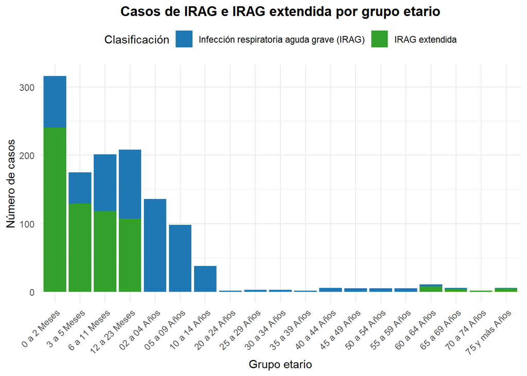

## Detecciones virales segun semana epidemiologica - UC-IRAG Hospital Avellaneda - Año 2024 y 2025

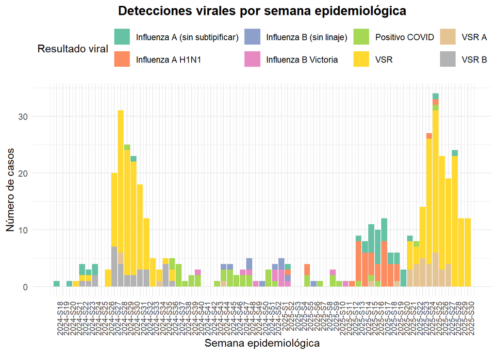

## Detecciones virales segun grupo etario - UC-IRAG Hospital Avellaneda - Año 2024 y 2025

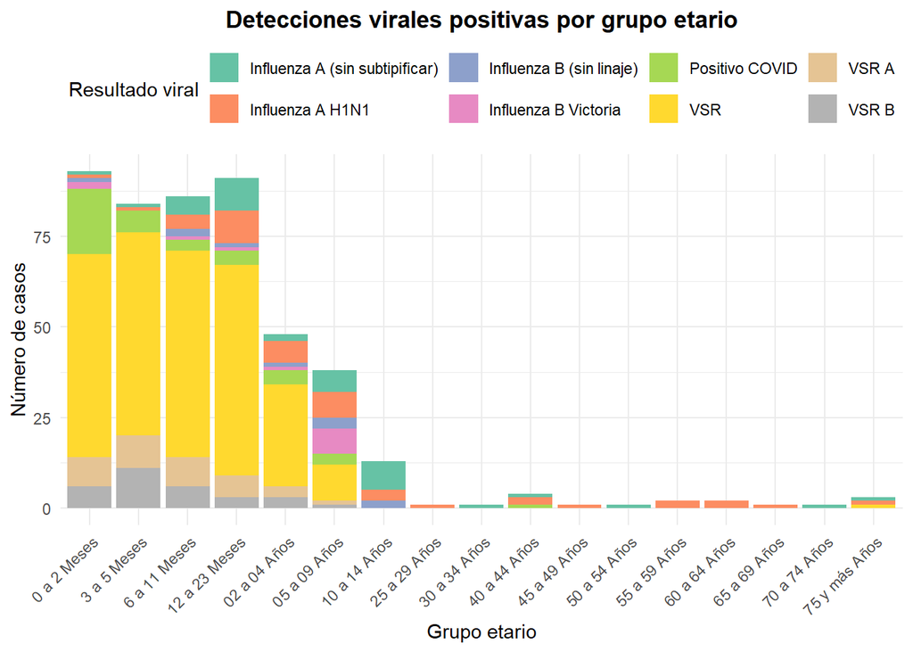

# **Difusión de la información**

A través de la notificación al SNVS 2.0 la información está al alcance del nivel provincial y nacional. Es importante que la unidad centinela difunda a los actores participantes de la estrategia los resultados de la vigilancia.

A nivel provincial la información es transmitida mediante un informe de vigilancia local trimestral, y a través de la Sala de Situación Provincial y el Boletín Epidemiológico Semanal. La periodicidad de estos métodos de difusión de la información podría variar según la situación epidemiológica vigente.